```python
from pathlib import Path
import pandas as pd
import numpy as np
import seaborn as sns
import matplotlib.pyplot as plt
import seaborn as sns
from sklearn import preprocessing
from sklearn.preprocessing import LabelEncoder
from sklearn.model_selection import train_test_split
from sklearn.neighbors import KNeighborsClassifier
from sklearn import datasets, linear_model, metrics
from sklearn.preprocessing import StandardScaler
from sklearn.tree import DecisionTreeClassifier
from sklearn.ensemble import RandomForestClassifier
from sklearn.neighbors import KNeighborsClassifier
from sklearn.model_selection import RandomizedSearchCV
from sklearn.metrics import accuracy_score, plot_confusion_matrix
from sklearn.metrics import classification_report
import plotly.express as px
from statsmodels.stats.outliers_influence import variance_inflation_factor
from sklearn.metrics import confusion_matrix
from sklearn.model_selection import cross_val_score
from sklearn.linear_model import LogisticRegression
from sklearn.metrics import roc_auc_score, roc_curve
from sklearn.metrics import mean_squared_error
from scipy.stats import chi2_contingency
from statsmodels.formula.api import ols
import statsmodels.api as sm

sns.set_style("whitegrid")
```

# 1. Introduction

The Black Friday 2022 witnessed consumers spend a record $9.12 billion online, according to Adobe, which monitors sales on retailer websites. It is obvious that E-Commerce is one of the biggest and competitive industries in the world right now. Then how can one E-Commerce have competitive advantage over others?

According to the survey regarding E-Commerce delivery, 66% of shoppers decided to buy products from one retailer over other because of the delivery services. The delivery service is playing a crucial role when it comes to the online shopping. Now online retailers are providing an estimated delivery date to customers since 83% of them anticipate a guaranteed arrival date. Even when the package is delayed, customers want the retailer to inform them about the delay and new estimated delivery date. The estimated delivery date and being delivered on-time are directly related to positive experiences from customers.

Based on this, the goal of our project is to **predict the on-time delivery** with data from E-Commerce company. We expect our analysis have valuable business insights regarding delivery services to increase the customer satisfaction for E-Commerce retailers.

We have two **SMART questions** here.

1. What features affect on-time delivery of products?
2. How can we predict on-time delivery with the higher accuracy for the E-Commerce company?

   This summary paper is organized as follows:
3. Introduction
4. Description of Data
5. EDA
6. Models
7. Conclusion
8. References

# 2. Description of Data

```python
data = pd.read_csv("dataset.csv")
data
```

|  | ID | Warehouse_block | Mode_of_Shipment | Customer_care_calls | Customer_rating | Cost_of_the_Product | Prior_purchases | Product_importance | Gender | Discount_offered | Weight_in_gms | Reached.on.Time_Y.N |
| --- | --- | --- | --- | --- | --- | --- | --- | --- | --- | --- | --- | --- |
| 0 | 1 | D | Flight | 4 | 2 | 177 | 3 | low | F | 44 | 1233 | 1 |
| 1 | 2 | F | Flight | 4 | 5 | 216 | 2 | low | M | 59 | 3088 | 1 |
| 2 | 3 | A | Flight | 2 | 2 | 183 | 4 | low | M | 48 | 3374 | 1 |
| 3 | 4 | B | Flight | 3 | 3 | 176 | 4 | medium | M | 10 | 1177 | 1 |
| 4 | 5 | C | Flight | 2 | 2 | 184 | 3 | medium | F | 46 | 2484 | 1 |
| ... | ... | ... | ... | ... | ... | ... | ... | ... | ... | ... | ... | ... |
| 10994 | 10995 | A | Ship | 4 | 1 | 252 | 5 | medium | F | 1 | 1538 | 1 |
| 10995 | 10996 | B | Ship | 4 | 1 | 232 | 5 | medium | F | 6 | 1247 | 0 |
| 10996 | 10997 | C | Ship | 5 | 4 | 242 | 5 | low | F | 4 | 1155 | 0 |
| 10997 | 10998 | F | Ship | 5 | 2 | 223 | 6 | medium | M | 2 | 1210 | 0 |
| 10998 | 10999 | D | Ship | 2 | 5 | 155 | 5 | low | F | 6 | 1639 | 0 |

10999 rows × 12 columns

We imported dataset as 'data'. The dataset is provided by E-commerce company who sells electronic products. The dataset contained 10999 observations of 12 variables.

```python
data.info()
data.isna().sum() / len(data)
```

```
<class 'pandas.core.frame.DataFrame'>
RangeIndex: 10999 entries, 0 to 10998
Data columns (total 12 columns):
 #   Column               Non-Null Count  Dtype
---  ------               --------------  -----
 0   ID                   10999 non-null  int64
 1   Warehouse_block      10999 non-null  object
 2   Mode_of_Shipment     10999 non-null  object
 3   Customer_care_calls  10999 non-null  int64
 4   Customer_rating      10999 non-null  int64
 5   Cost_of_the_Product  10999 non-null  int64
 6   Prior_purchases      10999 non-null  int64
 7   Product_importance   10999 non-null  object
 8   Gender               10999 non-null  object
 9   Discount_offered     10999 non-null  int64
 10  Weight_in_gms        10999 non-null  int64
 11  Reached.on.Time_Y.N  10999 non-null  int64
dtypes: int64(8), object(4)
memory usage: 1.0+ MB
```

```
ID                     0.0
Warehouse_block        0.0
Mode_of_Shipment       0.0
Customer_care_calls    0.0
Customer_rating        0.0
Cost_of_the_Product    0.0
Prior_purchases        0.0
Product_importance     0.0
Gender                 0.0
Discount_offered       0.0
Weight_in_gms          0.0
Reached.on.Time_Y.N    0.0
dtype: float64
```

There are no N/A values.

```python
# drop column that we are not using
data.drop(columns=['ID'], inplace=True)
data.info()
```

```
<class 'pandas.core.frame.DataFrame'>
RangeIndex: 10999 entries, 0 to 10998
Data columns (total 11 columns):
 #   Column               Non-Null Count  Dtype
---  ------               --------------  -----
 0   Warehouse_block      10999 non-null  object
 1   Mode_of_Shipment     10999 non-null  object
 2   Customer_care_calls  10999 non-null  int64
 3   Customer_rating      10999 non-null  int64
 4   Cost_of_the_Product  10999 non-null  int64
 5   Prior_purchases      10999 non-null  int64
 6   Product_importance   10999 non-null  object
 7   Gender               10999 non-null  object
 8   Discount_offered     10999 non-null  int64
 9   Weight_in_gms        10999 non-null  int64
 10  Reached.on.Time_Y.N  10999 non-null  int64
dtypes: int64(7), object(4)
memory usage: 945.4+ KB
```

We dropped the ID column as it was irrelevant.

```python
# differences between on-time and delayed delivery
data.groupby("Reached.on.Time_Y.N").describe().T
```

|  | Reached.on.Time_Y.N | 0 | 1 |
| --- | --- | --- | --- |
| Customer_care_calls | count | 4436.000000 | 6563.000000 |
|  | mean | 4.147656 | 3.991467 |
|  | std | 1.162771 | 1.122592 |
|  | min | 2.000000 | 2.000000 |
|  | 25% | 3.000000 | 3.000000 |
|  | 50% | 4.000000 | 4.000000 |
|  | 75% | 5.000000 | 5.000000 |
|  | max | 7.000000 | 7.000000 |
| Customer_rating | count | 4436.000000 | 6563.000000 |
|  | mean | 2.967989 | 3.005790 |
|  | std | 1.414808 | 1.412692 |
|  | min | 1.000000 | 1.000000 |
|  | 25% | 2.000000 | 2.000000 |
|  | 50% | 3.000000 | 3.000000 |
|  | 75% | 4.000000 | 4.000000 |
|  | max | 5.000000 | 5.000000 |
| Cost_of_the_Product | count | 4436.000000 | 6563.000000 |
|  | mean | 214.498647 | 207.289197 |
|  | std | 47.757432 | 48.054876 |
|  | min | 97.000000 | 96.000000 |
|  | 25% | 174.000000 | 167.000000 |
|  | 50% | 222.000000 | 209.000000 |
|  | 75% | 254.000000 | 249.000000 |
|  | max | 310.000000 | 310.000000 |
| Prior_purchases | count | 4436.000000 | 6563.000000 |
|  | mean | 3.670424 | 3.498095 |
|  | std | 1.525444 | 1.517285 |
|  | min | 2.000000 | 2.000000 |
|  | 25% | 3.000000 | 3.000000 |
|  | 50% | 3.000000 | 3.000000 |
|  | 75% | 4.000000 | 4.000000 |
|  | max | 10.000000 | 10.000000 |
| Discount_offered | count | 4436.000000 | 6563.000000 |
|  | mean | 5.545987 | 18.663721 |
|  | std | 2.877727 | 19.108797 |
|  | min | 1.000000 | 1.000000 |
|  | 25% | 3.000000 | 5.000000 |
|  | 50% | 6.000000 | 9.000000 |
|  | 75% | 8.000000 | 32.000000 |
|  | max | 10.000000 | 65.000000 |
| Weight_in_gms | count | 4436.000000 | 6563.000000 |
|  | mean | 4168.668395 | 3272.640104 |
|  | std | 1573.954178 | 1576.148391 |
|  | min | 1001.000000 | 1001.000000 |
|  | 25% | 4043.500000 | 1735.500000 |
|  | 50% | 4674.000000 | 3231.000000 |
|  | 75% | 5337.000000 | 4696.500000 |
|  | max | 6000.000000 | 7846.000000 |

We tried to see the differences on data by the on-time delivery. There are statistical differences in some variables by on-time delivery, including discount and weight. We will identify if this differences are statistically significant by visualization and hypothesis testings to answer the first SMART question which is "What features affect on-time delivery of products?".

# 3. EDA

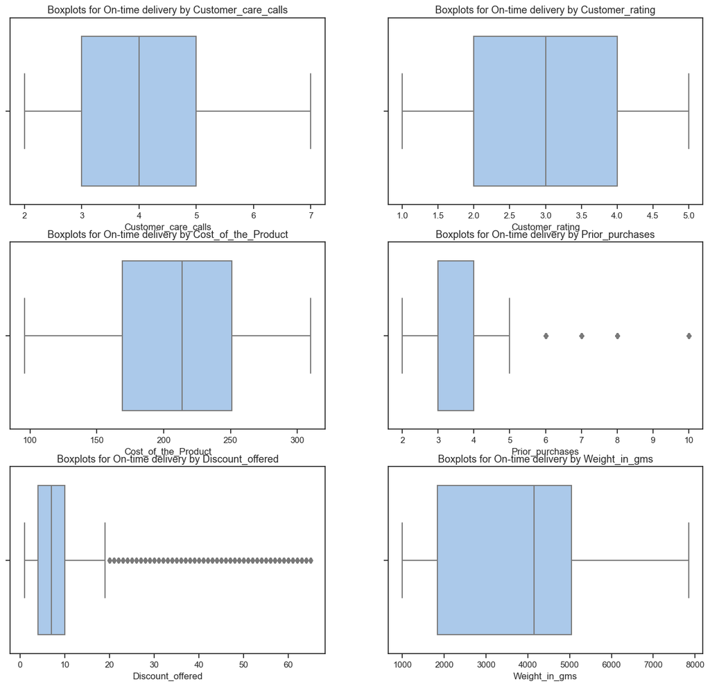

```python
# boxplots for On-time delivery
integer_cols = data.select_dtypes(include = ['int64'])
(integer_cols.head())
intcols = integer_cols.columns
intcols21 = intcols.drop(["Reached.on.Time_Y.N"])
plt.figure(figsize = (16, 20))
sns.set_theme(style="ticks", palette="pastel")
nplot = 1
for i in range(len(intcols21)):
    if nplot <= len(intcols21):
        ax = plt.subplot(4, 2, nplot)
        sns.boxplot(x = intcols21[i], data = data, ax = ax)
        plt.title("Boxplots for On-time delivery by "f"{intcols21[i]}" , fontsize = 13)
        nplot += 1
plt.show()
```

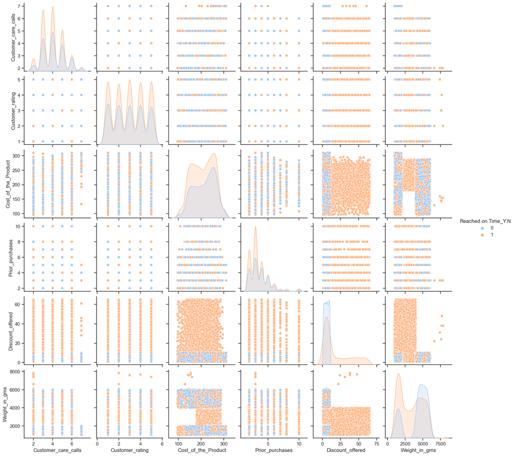

```python
# Pairplots for integer columns (Initial EDA)
sns.pairplot(data = integer_cols, hue = "Reached.on.Time_Y.N")
```

From the pairplot here, we can see the relationships between variables at once. We will continue our exploratory data analysis.

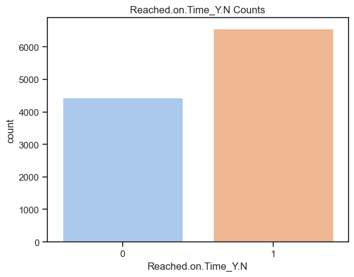

```python
# countplot for reached on time
sns.countplot(x ="Reached.on.Time_Y.N", data = data)
plt.title("Reached.on.Time_Y.N Counts")
```